# Homework 1

Elisabeth R Silver

02/02/2021

## Chatterjee-Price employee attitude dataset

In this dataset, each row is the proportion of favorable responses from a sample of employees (*n* = 35) at 30 companies for each column dimension (total *N* = 1050).

```r
data(attitude)
```

### Satisfaction with raises

The average (standard deviation) percent of employees satisfied with their employer’s raises is 64.63% (10.4%).

Visually, satisfaction with raises is roughly normally distributed, and there do not seem to be any outliers or egregious skew. The histogram has a roughly normal distribution, there are not any outlying points on the boxplot, and the points on the QQ plot mostly align with the QQ line, suggesting normality.

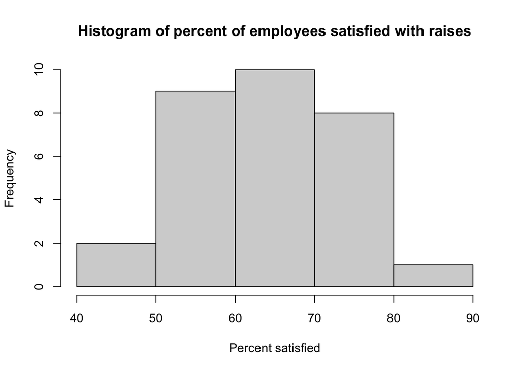

```r
#Create the histogram
hist(attitude$raises, main = 'Histogram of percent of employees satisfied with raises',
     xlab = "Percent satisfied")
```

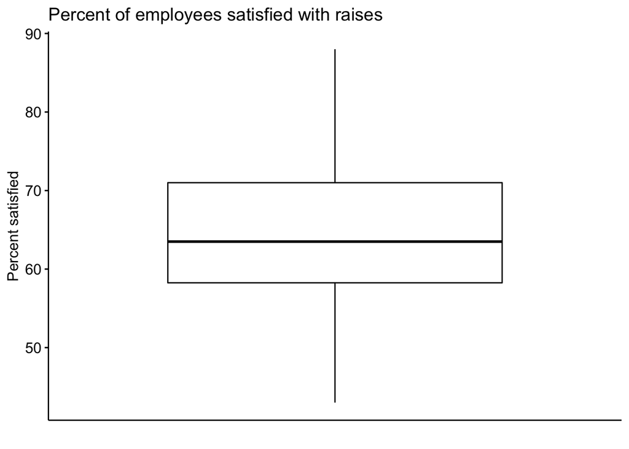

```r
#Create the boxplot
ggboxplot(attitude$raises, ylab="Percent satisfied",
          xlab = "",
          title = "Percent of employees satisfied with raises")+ rremove("x.ticks") + rremove("x.text")
```

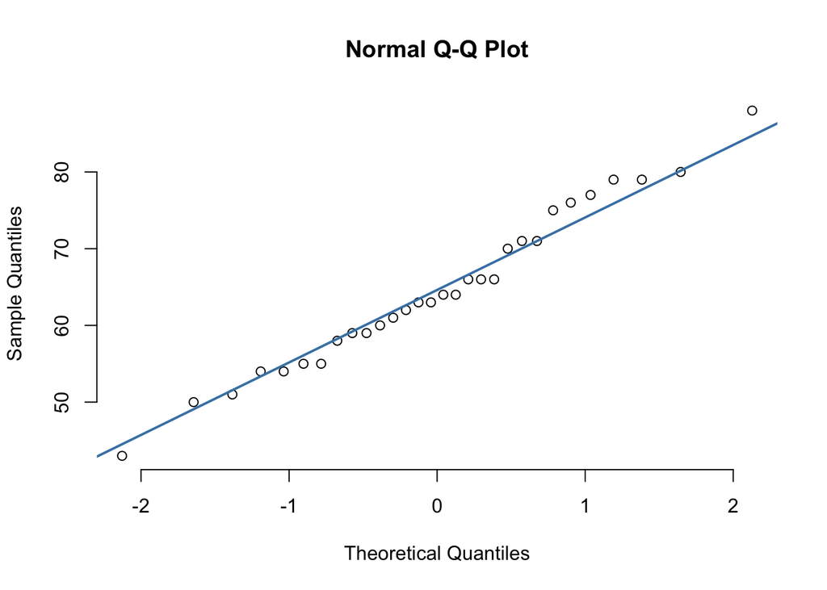

```r
#Create the QQPlot
qqnorm(attitude$raises, pch = 1, frame = FALSE)
qqline(attitude$raises, col = "steelblue", lwd = 2)
```

Statistically, the skew and excess kurtosis are not particularly large:

```r
#More descriptives
psych::describe(attitude$raises)
```

```
##    vars  n  mean   sd median trimmed   mad min max range skew kurtosis  se
## X1    1 30 64.63 10.4   63.5    64.5 11.12  43  88    45  0.2     -0.6 1.9
```

Given the approximately normal distribution of this variable, I do not think that the distribution would affect subsequent analyses.

### Satisfaction with handling of employee complaints

The average (standard deviation) percent of employees satisfied with their employer’s handling of employee complaints is 66.6% (13.31%).

Visually, satisfaction with handling of employee compaints is roughly normally distributed, and there do not seem to be any outliers or egregious skew. The histogram has a roughly normal distribution (although there is a slight negative skew), there are not any outlying points on the boxplot, and the points on the QQ plot mostly align with the QQ line:

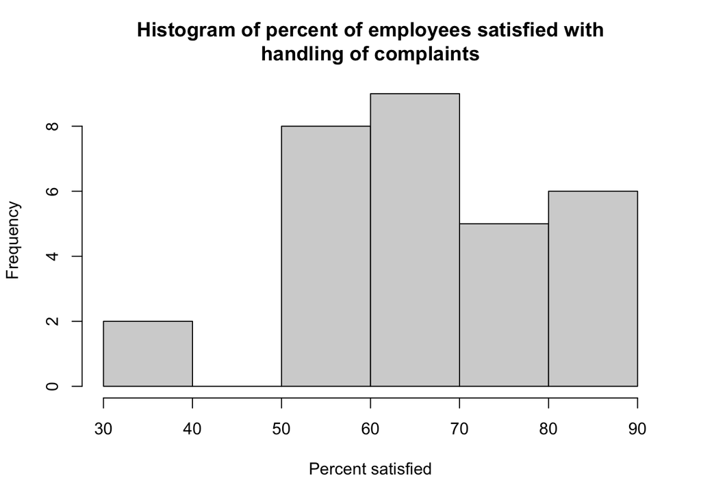

```r
#Create the histogram
hist(attitude$complaints,
     main = 'Histogram of percent of employees satisfied with\nhandling of complaints',
     xlab = "Percent satisfied")
```

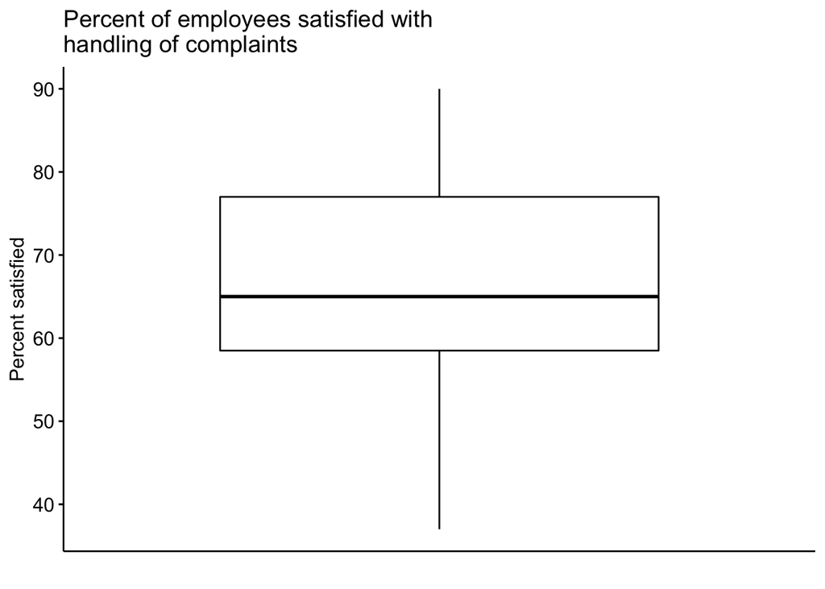

```r
#Create the boxplot
ggboxplot(attitude$complaints, ylab="Percent satisfied",
          xlab = " ", title = "Percent of employees satisfied with\nhandling of complaints") + rremove("x.ticks") + rremove("x.text")
```

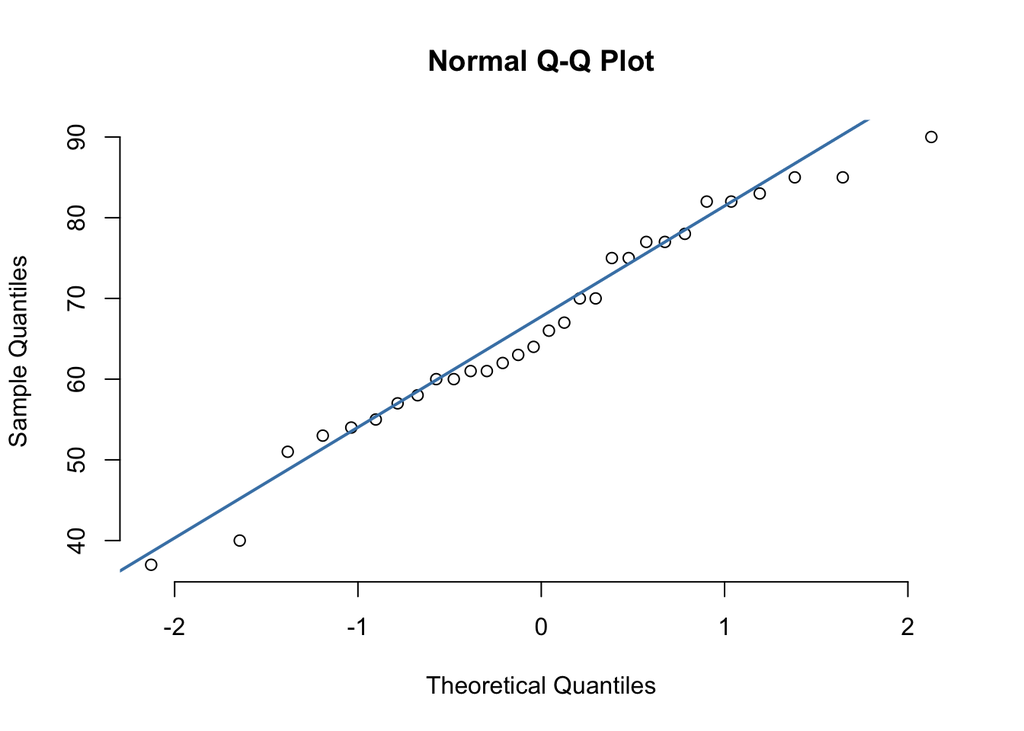

```r
#Create the QQPlot
qqnorm(attitude$complaints, pch = 1, frame = FALSE)
qqline(attitude$complaints, col = "steelblue", lwd = 2)
```

Statistically, the skew and excess kurtosis are not particularly large (although the skew is negative, as the above graphs suggest):

```r
#More descriptives
psych::describe(attitude$complaints)
```

```
##    vars  n mean    sd median trimmed   mad min max range  skew kurtosis   se
## X1    1 30 66.6 13.31     65   67.08 14.83  37  90    53 -0.22    -0.68 2.43
```

Given the approximately normal distribution of this variable, I do not think that the distribution would affect subsequent analyses. There aren’t any outliers that would require some sort of treatment.